# Linear Regression in R: A Tutorial on Frequentist & Bayesian Approaches

Lauren Alvis, PhD

2025-03-26

# 1 Overview

This tutorial provides a step-by-step guide to conducting linear regression analyses in R using two approaches: Frequentist (traditional) and Bayesian methods. It starts with a brief introduction to key R skills for data manipulation and analysis, then walks you through building, running, and interpreting regression models for each method.

You’ll learn how to construct models, interpret outputs, and generate well-formatted tables and visualizations to present your findings clearly. By the end, you’ll be equipped to perform and effectively communicate linear regression analyses!

# 2 Load Libraries

If this is your first time in R, open [this R script for installing required packages for this tutorial](https://lmalvis.github.io/Portfolio/Regression/install-packages-code.R).

You only need to install packages one time, but need to load each package every session (see below).

```r
knitr::opts_chunk$set(
  echo = TRUE,        # show code chunk in the output
  message = FALSE,    # hide package and function messages
  warning = FALSE    # hide warnings to keep output clean
)


########### Load Packages ################
library(rio) #import data

## manipulate data
library(plyr)
library(dplyr)
library(tidyverse)
library(janitor) # tabyl frequences function

## plotting
library(ggplot2)
library(corrplot) # plot correlation matrix

## custom tables
library(arsenal) # pretty descriptive tables
library(knitr) # kable html tables
library(gt) # tables
library(flextable) # pretty custom tables
library(officer) # customize word doc tables flexibly

## regression packages
library(bayestestR) # get bayes factors
library(rstanarm) # bayes regression (stan_glm)
library(bayestestR) # bayes regression (stan_glm)
library(bayesplot) # plot bayes
library(sjPlot) # regression tables
library(lm.beta) # std regression coef
library(jtools) # summ fn summary of reg results with CI
```

# 3 Data Preparation

## 3.1 Read in data

```r
df<-rio::import("exdata2.sav") # read in spss file
# rio::import can accommodate different file types
```

## 3.2 Clean data

```r
# subset dataset to include just the variables you're interested in
dat <- df %>%
  select(
 age,gend, racesimp3, black,latinx,white, #demographics
                   bereave, #bereavement indicator
  traumatotNB, #number of traumatic events
  pgd_timesince,  #time elapsed time death
                       cod,cod_st:cod_vio, #cause of death variables
                   belong, #belonging
                       pgd_sd,pgd_ex,pgd_cd, #maladaptive grief domains
                   ptsd_symp #ptsd symptoms
  )

# tell R which variables are categorical by converting them to "factor" variables and assign intuitive value labels for each category:
dat$gend.f<-factor(dat$gend, levels=c(0,1),
                       labels=c("Boy", "Girl"))

dat$racesimp3.f<-factor(dat$racesimp3, levels=c("White","Mixed","Latino/a/x","Black"))

dat$cod.f<-factor(dat$cod,
                  levels=c("Long-term illness","Short-term illness","Accident","Homicide","Suicide","Other Causes"))

dat <- dat %>% select(-c(cod,gend,racesimp3)) # use "-c" to remove specific columns from dataset, in this case, removing the original variables

# or you can convert multiple columns at once
#(useful when they have the same levels/labels)
binary_vars <- c("black","latinx", "white", "bereave",
                       "cod_st", "cod_lt","cod_acc",
                           "cod_murd","cod_sui","cod_vio")
dat <- dat %>%
  mutate(across(all_of(binary_vars), ~ factor(.,
                                        labels = c("No","Yes")),
                .names = "{.col}.f"))%>% #assign new factor var names ending in ".f"
  select(-all_of(binary_vars))
```

## 3.3 Inspect Data

### 3.3.1 Descriptive Statistics

Summarize descriptives statistics (mean, sd, frequency, ranges, missing data) for key variables and inspect to make sure it looks appropriate given the variables.

```r
# structure of dataset
str(dat)
# preview data
head(dat)

# summarize descriptive statistics for all vars in dat
summary(dat)
```

Or you can use the arsenal package to nicely formats key descriptives in a pretty table…

```r
mycontrols1 <- tableby.control(total=TRUE, test=T,
                               cat.simplify = FALSE,
                               numeric.stats=c("meansd",
                                               "range",
                                               "Nmiss"),
                            cat.stats=c("countpct","Nmiss"),
                            stats.labels=list(N='Count',
                                              meansd='Mean (SD)',
                                              range='Range',
                                              countpct='N (Percent)',
                                              Nmiss="Missing"))

# pretty var labels
var_labels <- c(
  racesimp3.f = "Race/Ethnicity",
  age = "Age",
  gend.f = "Gender",
  cod.f = "Cause of Death",
  bereave.f = "Bereaved",
  traumatotNB = "Number of Traumatic Events",
  belong = "Belonging",
  pgd_sd = "Separation Distress",
  pgd_ex = "Existential/Identity Distress",
  pgd_cd = "Circumstance-related Distress",
  ptsd_symp = "Posttraumatic Stress Symptoms",
  pgd_timesince = "Years Since Death"
)
attr(dat, "labels") <- var_labels

# list the variables to include in the table after "~" separated by "+"
table1 <- tableby(~ age + gend.f +  racesimp3.f + cod.f + bereave.f +
                    pgd_timesince +
                    traumatotNB + belong +
                    pgd_sd + pgd_ex + pgd_cd + ptsd_symp,
                  data = dat,
                  control=mycontrols1)

tab1<-summary(table1, digits=2,digits.pct=1, labelTranslations = var_labels)
kable(tab1)
```

|  | Overall (N=365) |
| --- | --- |
| **Age** |  |
| Mean (SD) | 13.62 (2.23) |
| Range | 9.00 - 18.00 |
| **Gender** |  |
| Boy | 135 (39.1%) |
| Girl | 210 (60.9%) |
| Missing | 20 |
| **Race/Ethnicity** |  |
| White | 85 (24.6%) |
| Mixed | 49 (14.2%) |
| Latino/a/x | 154 (44.6%) |
| Black | 57 (16.5%) |
| Missing | 20 |
| **Cause of Death** |  |
| Long-term illness | 87 (39.0%) |
| Short-term illness | 0 (0.0%) |
| Accident | 34 (15.2%) |
| Homicide | 32 (14.3%) |
| Suicide | 23 (10.3%) |
| Other Causes | 47 (21.1%) |
| Missing | 142 |
| **Bereaved** |  |
| No | 76 (20.8%) |
| Yes | 289 (79.2%) |
| **Years Since Death** |  |
| Mean (SD) | 2.53 (2.72) |
| Range | 0.00 - 12.00 |
| Missing | 99 |
| **Number of Traumatic Events** |  |
| Mean (SD) | 3.81 (2.63) |
| Range | 0.00 - 14.00 |
| Missing | 1 |
| **Belonging** |  |
| Mean (SD) | 47.34 (11.34) |
| Range | 14.00 - 63.00 |
| **Separation Distress** |  |
| Mean (SD) | 1.55 (0.97) |
| Range | 0.00 - 3.87 |
| Missing | 96 |
| **Existential/Identity Distress** |  |
| Mean (SD) | 1.32 (0.99) |
| Range | 0.00 - 4.00 |
| Missing | 96 |
| **Circumstance-related Distress** |  |
| Mean (SD) | 1.55 (0.96) |
| Range | 0.00 - 4.00 |
| Missing | 96 |
| **Posttraumatic Stress Symptoms** |  |
| Mean (SD) | 17.26 (10.97) |
| Range | 0.00 - 43.00 |
| Missing | 1 |

### 3.3.2 Bivariate Correlations

Another step for getting familiar with your data is to examine the correlations among your continuous variables.

```r
sub <-dat %>% select(-c(ends_with(".f"))) %>% na.omit() #removing categorical vars

Hmisc::rcorr(as.matrix(sub)) #nice package for corr matrix w/ p values
```

### 3.3.3 Correlations by Subgroup

Sometimes we might want to inspect what the correlations look like across subgroups…

```r
# Function to compute and plot correlations
plot_correlation <- function(data, group_name) {

  # Compute correlation matrix
  res <- cor(data, use = "pairwise.complete.obs")

  # Define variable labels
  cor_labels <- c(
    belong = "Belong",
    pgd_sd = "SD",
    pgd_ex = "EID",
    pgd_cd = "CRD",
    ptsd_symp = "PTSD",
    traumatotNB = "Trauma",
    age = "Age",
    pgd_timesince = "TimeSince"
  )

  # Rename matrix labels
  colnames(res) <- cor_labels[colnames(res)]
  rownames(res) <- cor_labels[rownames(res)]

  # Plot correlation matrix
  corrplot::corrplot(res, type = "upper",
                      diag = FALSE, order = "original",
                      insig = "blank", sig.level = 0.05,
                      tl.col = "black", tl.srt = 45,
                      addCoef.col = "black", number.cex = 0.7,
                      title = paste("Correlation Plot -", group_name))
}

# Subset data by race/ethnicity
b <- dat %>% filter(racesimp3.f == "Black")%>% select(-c(ends_with(".f")))
l <- dat %>% filter(racesimp3.f == "Latino/a/x")%>% select(-c(ends_with(".f")))
m <- dat %>% filter(racesimp3.f == "Mixed")%>% select(-c(ends_with(".f")))
w <- dat %>% filter(racesimp3.f == "White")%>% select(-c(ends_with(".f")))
```

#### 3.3.3.1 Black youth

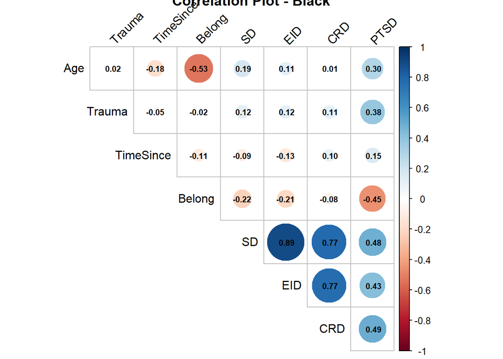

```r
plot_correlation(b, "Black")
```

#### 3.3.3.2 Latina/o/x youth

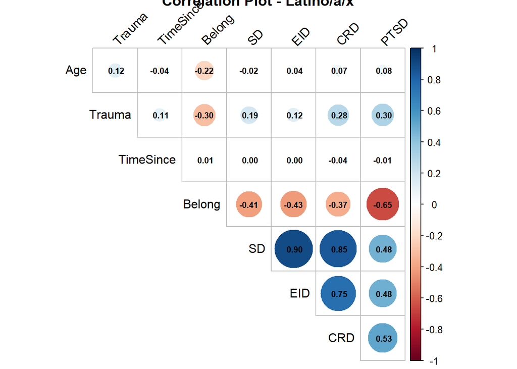

```r
plot_correlation(l, "Latino/a/x")
```

#### 3.3.3.3 Multiracial youth

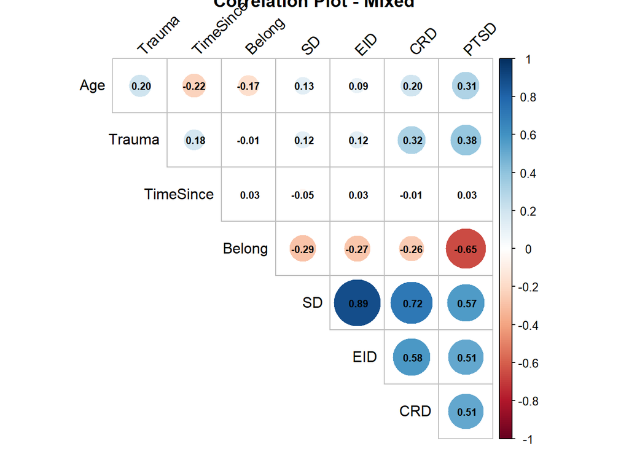

```r
plot_correlation(m, "Mixed")
```

#### 3.3.3.4 White youth

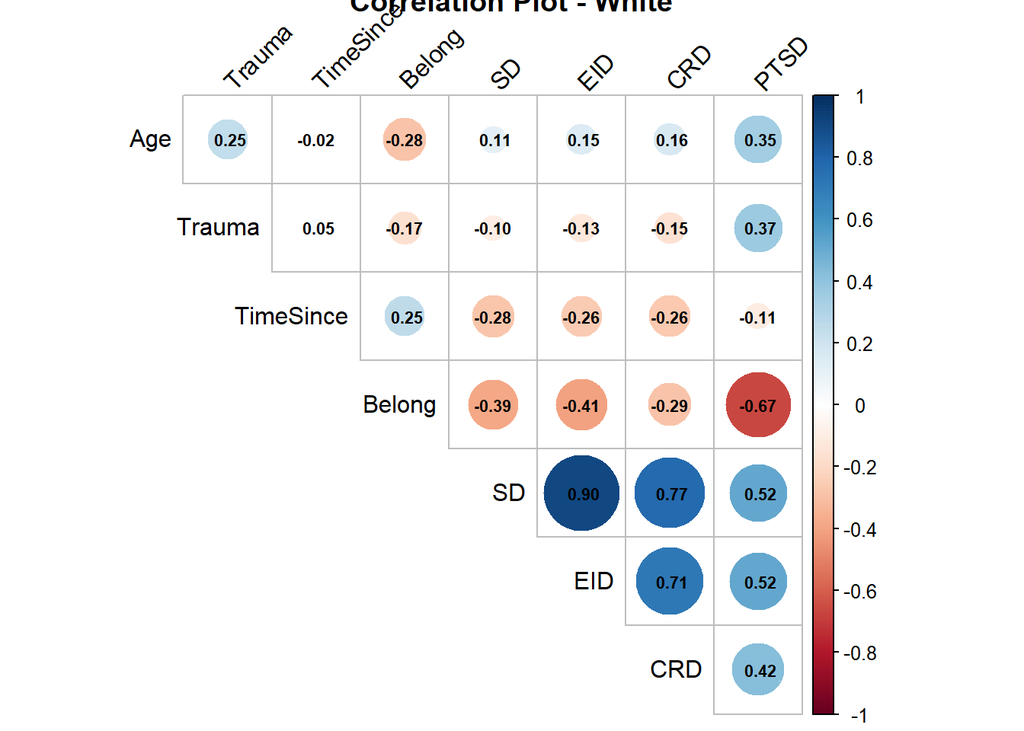

```r
plot_correlation(w, "White")
```

### 3.3.4 Scatterplots

Inspect raw associations between independent variable (IV) and dependent variable (DV) via scatterplots with univariate distribution of each variable in the margins.

We’re looking for skewness, kurtosis, outliers, etc.

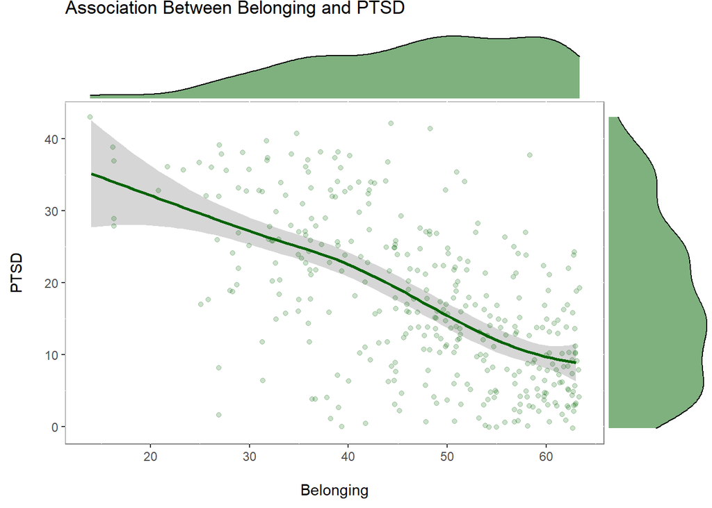

```r
#example scatter plot:
d <- ggplot(dat, aes(belong, ptsd_symp)) +
  geom_smooth(color="darkgreen") +
  geom_jitter(alpha=.2, color="darkgreen") +
  ggtitle("Association Between Belonging and PTSD")+
  xlab("Belonging") +
  ylab("PTSD") +
  theme(
    axis.title.x = element_text(margin = unit(c(5, 0, 0, 0), "mm")),
    axis.title.y = element_text(margin = unit(c(0, 5, 0, 0), "mm")),
    panel.background = element_rect(fill = "white", colour = "grey50"))
d <-  ggExtra::ggMarginal(d, type = "density", fill="darkgreen", alpha=.5)

d
```

# 4 Frequentist Linear Regression

A **frequentist approach** to regression treats the data we collect as one of many possible samples from a larger population, using mathematical techniques to find the best-fitting model that explains relationships between variables. It relies on probabilities to determine whether patterns in the data are strong enough to confidently conclude that they are not due to random chance.

In this example, we will use a frequentist linear regression model to test the association between feelings of belonging and youth mental health outcomes, specifically posttraumatic stress symptoms and maladaptive grief reactions. To account for potential confounding factors, we typically include covariates like age and gender, as well as other relevant variables that might influence our outcomes. This helps us isolate the unique association between our independent variable (IV) and dependent variables (DVs), providing a clearer understanding of their relationship.

## 4.1 Build The Model

- Start by assigning a name to your model using the `<-` operator.
- Use the lm() function to specify the regression model.
- Inside lm(), here is how you build your model:  
  [Outcome Variable] ~ [Predictor1] + [Predictor2] + [covariate1] + [covariate2]…, data= [YourData]
- The data = [YourData] part is just telling R where to find the variables you’re using. Make sure your dataset and variable name matches exactly—R is picky about that (**case-sensitive!**).

Let’s test PTSD as the outcome first and include our covariates of trauma exposure, gender, age, and race and ethnicity…

```r
model1<-lm(ptsd_symp ~  age +  gend.f + black.f + latinx.f +
         traumatotNB +
        belong,
       data=dat)
```

## 4.2 Assumption Check

Before interpreting our results, we need to ensure that our data meet the assumptions of linear regression. Violating these assumptions can lead to biased estimates and incorrect conclusions. Below are the core assumptions and how to check them in R.

1. Linearity  
   The relationship between IV and DV should be linear.  
   ✔ Check: Residuals vs. Fitted plot—look for a random scatter of points (no clear pattern).

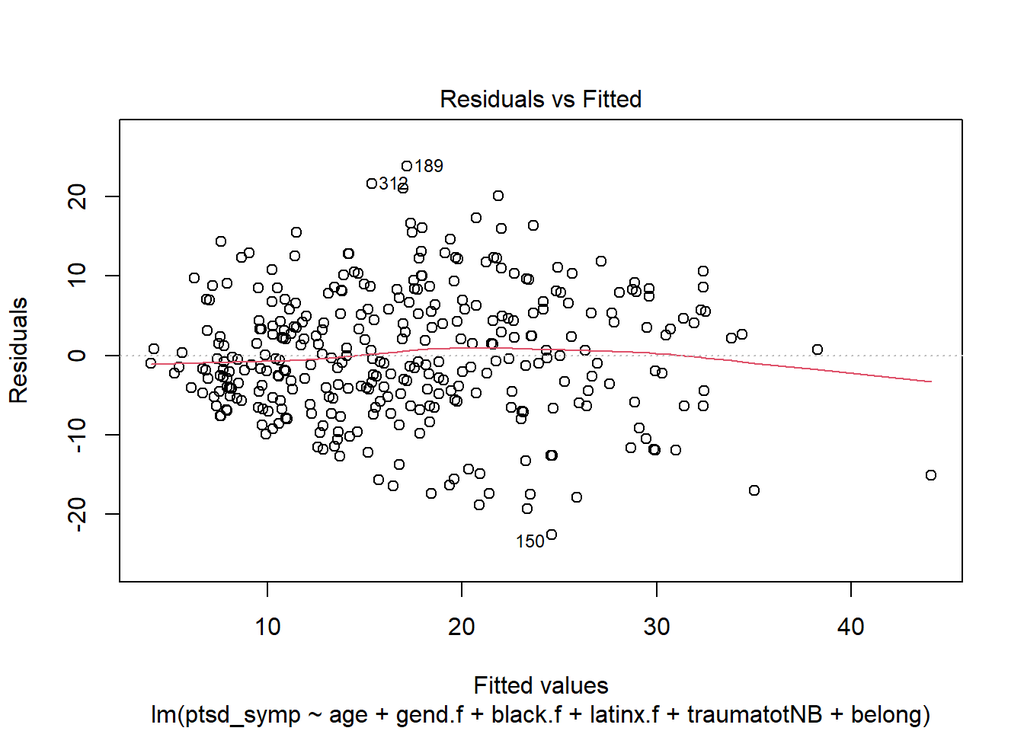

```r
# linearity
plot(model1, which = 1)  # Residuals vs. Fitted plot
```

2. Independence of Errors  
   Residuals (errors) should not be correlated.  
   ✔ Check: Durbin-Watson test—values close to 2 suggest no autocorrelation.

```r
lmtest::dwtest(model1)  # Test for autocorrelation of residuals
```

```
##
##  Durbin-Watson test
##
## data:  model1
## DW = 1.972, p-value = 0.3889
## alternative hypothesis: true autocorrelation is greater than 0
```

3. Homoscedasticity (Constant Variance of Residuals)  
   The variance of residuals should be roughly equal across all levels of the independent variables.  
   ✔ Check: Scale-Location plot (should show an even spread of points) and Breusch-Pagan test.

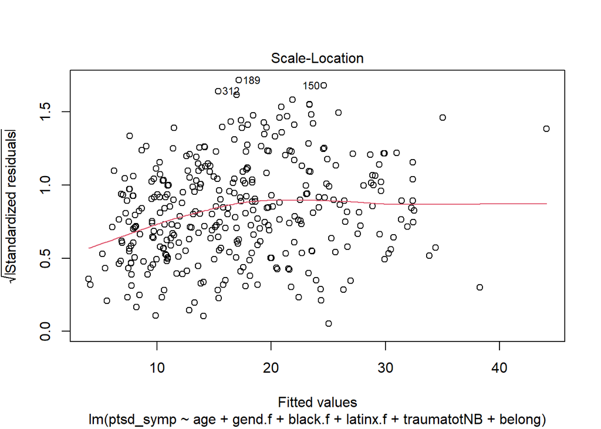

```r
plot(model1, which = 3)  # Scale-Location plot
```

```r
lmtest::bptest(model1) # Breusch-Pagan test for heteroscedasticity
```

```
##
##  studentized Breusch-Pagan test
##
## data:  model1
## BP = 17.817, df = 6, p-value = 0.006706
```

The Scale-Location plot shows some mild heteroscedasticity, supported by upward trending line and the significant Breusch-Pagan test.

Since the heteroscedasticity is mild, we could consider using robust standard errors (HC3) to estimate the model, which is a simple and effective fix.

4. Normality of Residuals  
   Residuals should be approximately normally distributed.  
   ✔ Check: Histogram, Q-Q plot, and Shapiro-Wilk test.

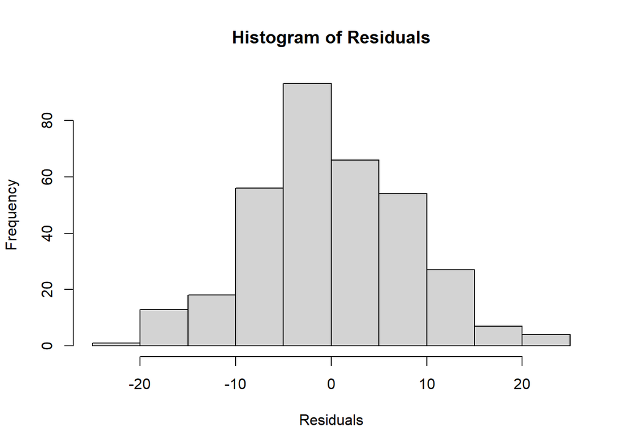

```r
hist(residuals(model1), main = "Histogram of Residuals", xlab = "Residuals")
```

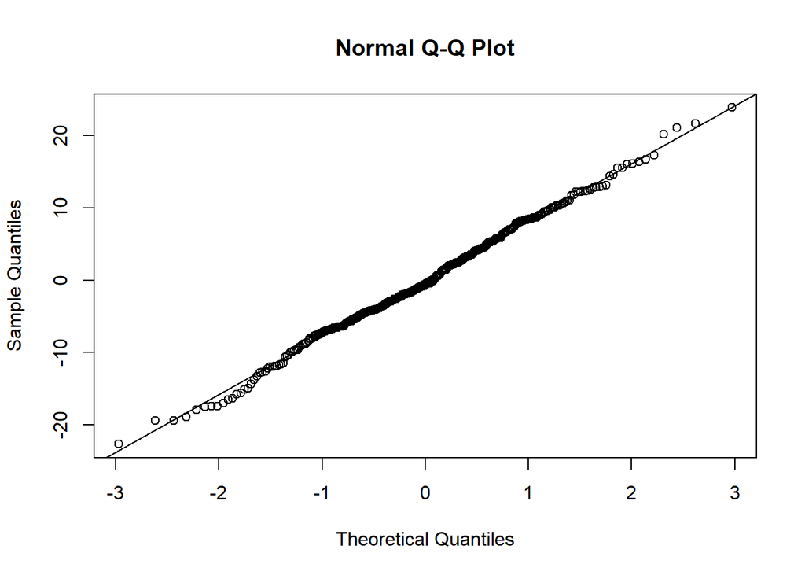

```r
qqnorm(residuals(model1))
qqline(residuals(model1))
```

```r
shapiro.test(residuals(model1))
```

```
##
##  Shapiro-Wilk normality test
##
## data:  residuals(model1)
## W = 0.99643, p-value = 0.6521
```

5. Multicollinearity (High Correlation Between Predictors)  
   Highly correlated predictors can distort estimates and inflate standard errors.  
   ✔ Check: Variance Inflation Factor (VIF)—values above 5-10 indicate multicollinearity.

```r
car::vif(model1)  # Check for multicollinearity
```

```
##         age      gend.f     black.f    latinx.f traumatotNB      belong
##    1.081159    1.065350    1.154673    1.144110    1.057177    1.131267
```

## 4.3 Model Results

To view the model results, I like using `jtools::summ()`. This function gives you a nicely formatted summary, showing the estimated effects (coefficients), how confident we are about these estimates (confidence intervals), and whether each predictor is statistically significant. Use confint = TRUE to show those confidence intervals and digits = 3 to keep the numbers readable.

> **How to Interpret Output:**
> - **Intercept:** The baseline level of our outcome (PTSD symptoms) when all predictors are zero. Think of it as the “starting point” of your outcome.
> - **Coefficients (Estimates):** How much the outcome is expected to change with a one-unit change in a predictor, holding other variables constant (i.e., assuming all else stays the same).

>   ```
>   * Positive coefficient → Outcome increases.
>   * Negative coefficient → Outcome decreases.
>   * Pay attention to the *size* of the coefficient to see if the change in outcome is meaningful in practice.
>   ```

> - **Standard Error (SE):** Tells you how precise your estimate is. Smaller SE = more confidence in the coefficient’s exact value.
> - **Confidence Intervals (CI):** The range where the true effect *likely* falls. If a CI doesn’t include zero, the effect is likely significant. A 95% CI means we’re 95% confident the true value is inside this range.
> - **p-value:** Measures statistical significance of the effect. If p < .05, there’s strong evidence that the predictor has a real (non-zero) effect on the outcome.

> *Important Considerations:*
> - **Statistical Significance ≠ Practical Importance** – Even if p < .05, the effect size might be too small to matter in the real world.
> - **More tests = Higher risk of false positives** – Running lots of models increases the chance of detecting effects that aren’t actually there (Type I error).

```r
jtools::summ(model1, confint = TRUE, digits = 3) # view results
```

| Observations | 339 (26 missing obs. deleted) |
| --- | --- |
| Dependent variable | ptsd_symp |
| Type | OLS linear regression |

| F(6,332) | 45.331 |
| --- | --- |
| R² | 0.450 |
| Adj. R² | 0.440 |

|  | Est. | 2.5% | 97.5% | t val. | p |
| --- | --- | --- | --- | --- | --- |
| (Intercept) | 33.605 | 25.776 | 41.433 | 8.444 | 0.000 |
| age | 0.120 | -0.293 | 0.534 | 0.573 | 0.567 |
| gend.fGirl | 2.373 | 0.532 | 4.215 | 2.535 | 0.012 |
| black.fYes | 2.817 | 0.546 | 5.088 | 2.440 | 0.015 |
| latinx.fYes | 0.204 | -1.655 | 2.063 | 0.216 | 0.829 |
| traumatotNB | 1.029 | 0.687 | 1.371 | 5.921 | 0.000 |
| belong | -0.512 | -0.593 | -0.431 | -12.442 | 0.000 |

Standard errors: OLS

### 4.3.1 Plot Effects

Forest-plot of standardized coefficients.

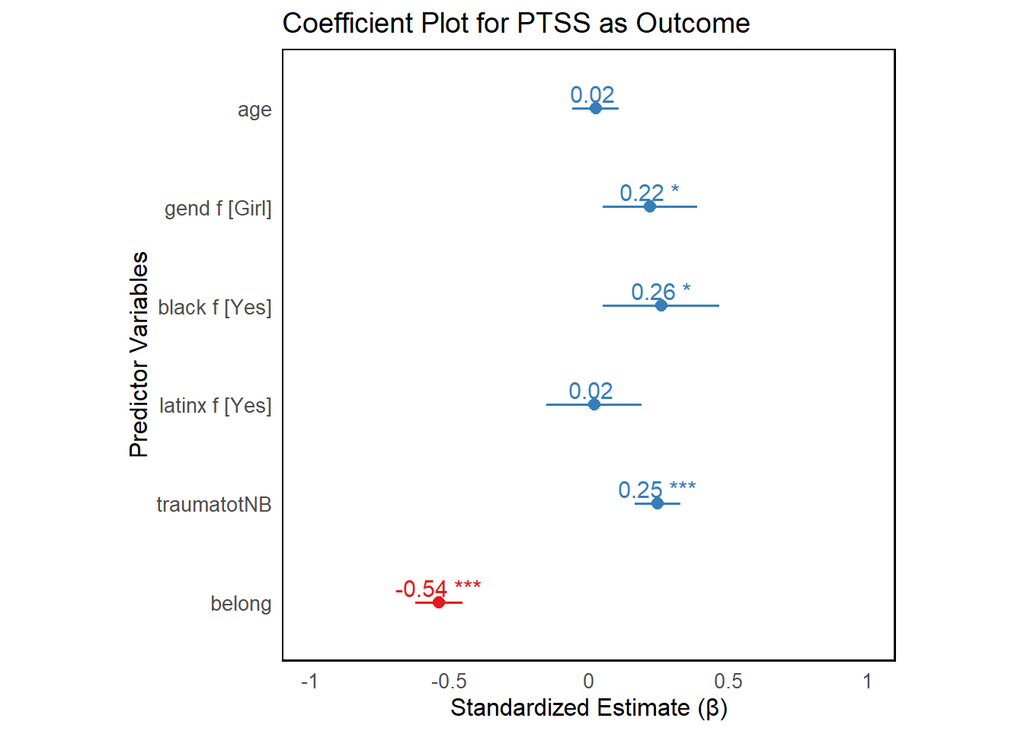

```r
plot_model(model1, type = "std", show.values = TRUE,
           show.p = TRUE,
           ci.lvl = 0.95,
           axis.labels = "") +
  theme_minimal()+
  labs(title = "Coefficient Plot for PTSS as Outcome",
       y = "Standardized Estimate (β)", x = "Predictor Variables")+
      theme(plot.title = element_text(size = 14, hjust = 0),
        axis.title = element_text(size = 12),
        axis.text = element_text(size = 10),
        panel.border = element_rect(color = "black", fill = NA, linewidth = 0.8),
        panel.grid = element_blank(),
        legend.position = "none",
        aspect.ratio = 1)
```

You can also plot the predicted values (i.e., marginal effects) of the outcome at various levels of your predictor when all other variables are held constant.

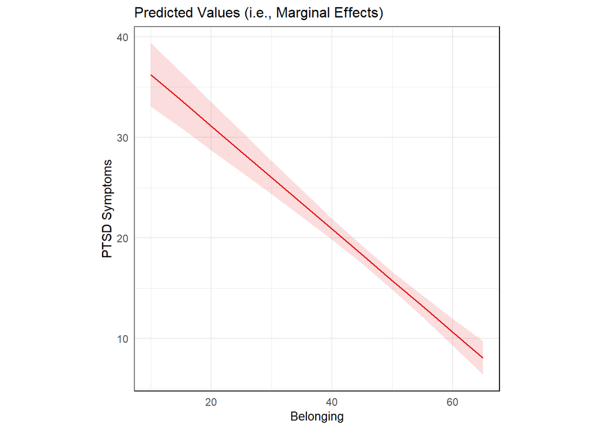

```r
plot_model(model1, type = "eff",
           terms=c("belong")) +
  theme_minimal()+
  labs(title = "Predicted Values (i.e., Marginal Effects)",
       y = "PTSD Symptoms", x = "Belonging")+
    theme(plot.title = element_text(size=12, hjust=0),
        axis.title.x = element_text(size=10),
        legend.position = "none", aspect.ratio=1,
        panel.border = element_rect(color="black", fill=NA))
```

### 4.3.2 Table Results

```r
tab_model(model1,
          string.se = "SE",show.obs = T,
          string.est = "Unstandardized Estimate",
          show.se = TRUE, p.style="stars",
           dv.labels = c("PTSD"),
        pred.labels=list("(Intercept)"= "Intercept",
                              age= "Age",
                         gend.fGirl="Gender",
                         black.fYes="Black",
                         latinx.fYes="Latinx",
                         traumatotNB="Trauma Exposure",
                         belong="Belonging"))
```

PTSD

Predictors

Unstandardized Estimate

SE

CI

Intercept

33.60 ***

3.98

25.78 – 41.43

Age

0.12

0.21

-0.29 – 0.53

Gender

2.37 *

0.94

0.53 – 4.21

Black

2.82 *

1.15

0.55 – 5.09

Latinx

0.20

0.95

-1.65 – 2.06

Trauma Exposure

1.03 ***

0.17

0.69 – 1.37

Belonging

-0.51 ***

0.04

-0.59 – -0.43

Observations

339

R<sup>2</sup> / R<sup>2</sup> adjusted

0.450 / 0.440

- p<0.05 ** p<0.01 *** p<0.001

Or you can use the `apaTables` package to make an APA formatted table in Word!

```r
table2 <- apaTables::apa.reg.table(model1,
                        table.number = 2)
# optionally save the apa table to a word doc
#apaTables::apa.save(filename = "apa-corr-table.doc",table2)
```

# 5 Bayesian Linear Regression

A Bayesian approach to regression treats uncertainty more explicitly by combining prior beliefs (what we know before seeing the data) with observed data to update our understanding of the relationship between variables. Using Bayes’ theorem, it provides a probability distribution for the model’s parameters, helping us quantify our confidence in different possible values rather than just giving a single “best estimate.”

Bayesian regression adds flexibility and better handles uncertainty, while frequentist methods are simpler and more widely used. If you need better estimates for small or uncertain data, more intuitive probability statements, or to integrate past research, Bayesian regression is a great option!

Here are the key differences:

1. **Bayesian Regression Lets You Use Prior Knowledge**
- In frequentist regression, all estimates come only from the data in your study.
- In Bayesian regression, you can incorporate prior knowledge (e.g., past studies, expert opinion) to improve estimates, especially when you have a small sample size or uncertain data.

  💡 Example: If past research suggests that social support reduces PTSD symptoms, Bayesian methods allow you to formally include that expectation in your analysis instead of treating every study as a blank slate.
2. **Bayesian Methods Provide Credible Intervals Instead of Confidence Intervals**
- Frequentist Confidence Intervals (CIs) tell you where the estimate would fall in repeated experiments (which can be hard to interpret).
- Bayesian Credible Intervals (CrIs) give you a direct probability statement about where the true effect likely falls.

  💡 Example: A 95% frequentist CI means “if we repeated this study many times, 95% of the intervals would contain the true effect.” vs A 95% Bayesian CrI means “there’s a 95% probability that the true effect is within this range.”
3. **Works Better with Small or Messy Data**
- Frequentist methods rely on large samples to give stable estimates.
- Bayesian methods work better for small datasets, missing data, or noisy measurements because they combine your data with prior knowledge for more reliable results.

  💡 Example: If you have only 30 participants in a PTSD study, frequentist regression might give unreliable p-values. Bayesian regression can borrow strength from past research to stabilize your estimates.
4. **No Need to Rely on p-values**
- Frequentist methods rely on p-values to test if an effect is “statistically significant” (p < .05), but p-values can be misleading and are often misinterpreted.
- Bayesian regression directly tells you how probable an effect is, rather than just whether it’s statistically significant.

  💡 Example: Instead of saying “p = .049, so the effect is significant,” a Bayesian approach might say: “There’s an 85% chance that social support reduces PTSD symptoms by at least 3 points.”

## 5.1 Build The Model

For a Bayesian regression model, we use stan_glm() from the rstanarm package. It’s the bayesian version of the lm() function.

Nearly the same as before:  
[UniqueModelName]<-*stan_glm*([Outcome] ~ [Predictor1] + [Predictor2] + [covariate1] + [covariate2…], data=[YourData])

Default settings are described below from this [r-bloggers tutorial](https://www.r-bloggers.com/2020/04/bayesian-linear-regression/):

- family: by default this function uses the gaussian distribution as we do with the classical glm function to perform lm model.
- prior: The prior distribution for the regression coefficients, By default the normal prior is used. There are subset of functions used for the prior provided by rstanarm like, student t family, laplace family…ect. To get the full list with all the details run this command `?priors`. If we want a flat uniform prior we set this to NULL.
- prior_intercept: prior for the intercept, can be normal, student_t , or cauchy. If we want a flat uniform prior we set this to NULL.  
  prior_aux: prior fo auxiliary parameters such as the error standard deviation for the gaussion family.
- algorithm: The estimating approach to use. The default is “sampling MCMC1.
- QR: FALSE by default, if true QR decomposition applied on the design matrix if we have large number of predictors.
- iter: is the number of iterations if the MCMC method is used, the default is 2000.
- chains: the number of Markov chains, the default is 4.
- warmup: also known as burnin, the number of iterations used for adaptation, and should not be used for inference. By default it is half of the iterations.

```r
model1b <- rstanarm::stan_glm(ptsd_symp ~  age +  gend.f +
                                black.f + latinx.f +
         traumatotNB +
        belong,
       data=dat, seed=123)

# Save results for making a table or further analysis:
m1 <- bayestestR::describe_posterior(model1b, test="all")
posteriors1 <- insight::get_parameters(model1b)
```

## 5.2 Model Results

**How to Interpret Bayes Results?**

> Bayesian regression gives us a full picture of possible effects rather than a single number. Instead of just asking “Is there an effect?”, it also helps us understand “How strong is the evidence for this effect?” and “Does it matter in the real world?”

Below is a breakdown of the key terms and how to make sense of them.

**Posterior Distributions**

- Instead of estimating just one effect size, Bayesian models generate a whole range of possible values based on the data.
- Think of it as a set of “best guesses” rather than a single number.

**Median (Best Estimate of the Effect)**

- The middle point of the posterior distribution. This is the most likely estimate of how much the predictor affects the outcome.
- **Example:** If the median for “social support” is **-0.50**, it suggests that increasing social support by one unit is associated with a **0.50 decrease in PTSD symptoms** on average.

**Credible Interval (CrI)**

- Shows the range of values where the true effect likely falls.
- **A 95% CrI means:** “We are 95% sure the true effect is somewhere in this range.”
- **If the entire interval is above or below zero, the effect is likely real.**
- **If the interval includes zero, we cannot rule out that there is no effect.**

**Probability of Direction (pd)**

- Tells us how confident we are about the direction of the effect (positive or negative).
- **pd = 100%?** We are fully confident about the effect’s direction.
- **pd = 98%?** There’s a **98% chance** the effect is positive (or negative).

**Region of Practical Equivalence (ROPE)**

- Answers the question, **“Is this effect large enough to matter?”**
- **If the entire 95% credible interval is inside the ROPE**, the effect is so small that it’s **practically negligible**.
- If the CrI is completely *outside* the ROPE, the “null hypothesis” is “rejected” aka the effect is **meaningful** (not just statistical noise).
- By default (according to Cohen, 1988), the ROPE (i.e., area of practically equivalant to zero) is [-0.1 x SDy,0.1 x SDy].

**Bayes Factor (BF)**

- Tells us how much evidence supports an effect.
- **BF > 1** → Evidence **supports** an effect.
- **BF < 1** → More evidence **against** an effect.
- **BF = 3?** The data is **3x more likely** to support the effect than not.

```r
# summarize results to see what we learned from the model
bayestestR::describe_posterior(model1b, test="all")
```

```
## Summary of Posterior Distribution
##
## Parameter   | Median |         95% CI | p (MAP) |     pd | p (ROPE) |   ps
## --------------------------------------------------------------------------
## (Intercept) |  33.78 | [25.92, 41.43] |  < .001 |   100% |   < .001 | 1.00
## age         |   0.12 | [-0.28,  0.54] |  0.823  | 71.25% |   > .999 | 0.00
## gend.fGirl  |   2.38 | [ 0.52,  4.15] |  0.049  | 99.38% |   0.091  | 0.91
## black.fYes  |   2.80 | [ 0.50,  5.11] |  0.057  | 99.02% |   0.066  | 0.93
## latinx.fYes |   0.17 | [-1.66,  2.08] |  0.981  | 58.10% |   0.743  | 0.17
## traumatotNB |   1.03 | [ 0.68,  1.38] |  < .001 |   100% |   0.619  | 0.38
## belong      |  -0.51 | [-0.59, -0.43] |  < .001 |   100% |   > .999 | 0.00
##
## Parameter   |          ROPE | % in ROPE | Equivalence (ROPE) |       BF |  Rhat |     ESS
## -----------------------------------------------------------------------------------------
## (Intercept) | [-1.09, 1.09] |        0% |           Rejected | 2.53e+05 | 0.999 | 5371.00
## age         | [-1.09, 1.09] |      100% |           Accepted |    0.022 | 0.999 | 5765.00
## gend.fGirl  | [-1.09, 1.09] |     7.00% |          Undecided |    0.388 | 0.999 | 5300.00
## black.fYes  | [-1.09, 1.09] |     4.47% |          Undecided |    0.319 | 1.000 | 5211.00
## latinx.fYes | [-1.09, 1.09] |    78.16% |          Undecided |    0.018 | 1.001 | 5448.00
## traumatotNB | [-1.09, 1.09] |    62.53% |          Undecided | 2.32e+03 | 1.000 | 5436.00
## belong      | [-1.09, 1.09] |      100% |           Accepted | 5.65e+09 | 0.999 | 6263.00
```

### 5.2.1 Bayesian Regression Table

Bayesian Regression Results<sup>1</sup>

| Parameter | PTSS Median | PTSS 95% CI Lower | PTSS 95% CI Upper | PTSS pd | PTSS ROPE % | PTSS BF |
| --- | --- | --- | --- | --- | --- | --- |
| (Intercept) | 33.78 | 25.92 | 41.43 | 1.00 | 0.00 | 12.44 |
| age | 0.12 | −0.28 | 0.54 | 0.71 | 1.00 | −3.82 |
| gend.fGirl | 2.38 | 0.52 | 4.15 | 0.99 | 0.07 | −0.95 |
| black.fYes | 2.80 | 0.50 | 5.11 | 0.99 | 0.04 | −1.14 |
| latinx.fYes | 0.17 | −1.66 | 2.08 | 0.58 | 0.78 | −4.03 |
| traumatotNB | 1.03 | 0.68 | 1.38 | 1.00 | 0.63 | 7.75 |
| belong | −0.51 | −0.59 | −0.43 | 1.00 | 1.00 | 22.45 |

<sup>1</sup> CI = Credible Interval. pd = Probability of Direction. ROPE % = Region of Practical Equivalence Percentage. BF = Bayes Factor.

**How to Read the Results Table**

1. **Check the Median** – This is the **best guess** of the effect size.
2. **Look at the 95% CrI** – If the entire interval is **above or below zero**, the effect is likely real.
3. **Check the pd** – If pd is high (e.g., 98%+), we are **highly certain** about the effect’s direction.
4. **See if ROPE % is close to 0%** – If so, the effect **is large enough to matter.**
5. **Look at the BF** – If BF is well above 1, there is **strong evidence for the effect**.

### 5.2.2 Plot Posterior Distributions

Plotting the posterior distributions helps us visualize the “spread” of possible values for each parameter. This spread shows us how certain or uncertain we are about our estimates and can help us understand the range of plausible effects.

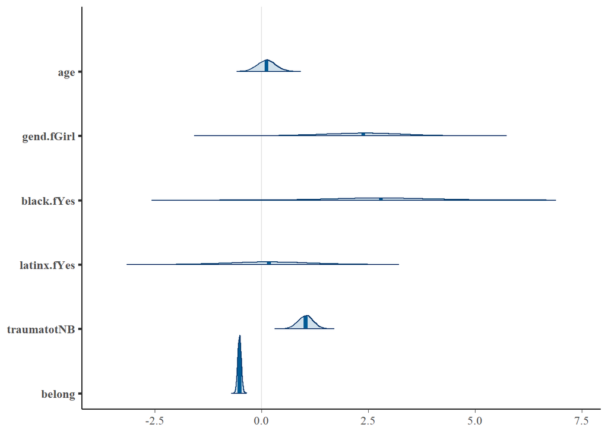

```r
mcmc_areas(posteriors1,
           pars = c("age","gend.fGirl","black.fYes","latinx.fYes","traumatotNB", "belong"),
           prob = 0.95)
```

- Narrower distributions indicate more certainty in estimates, while wider ones suggest more variability.
- If the CI is wide (shaded region), it suggests high uncertainty in that parameter estimate.

Or you can plot the posterior medians and credible intervals using `mcmc_intervals()`

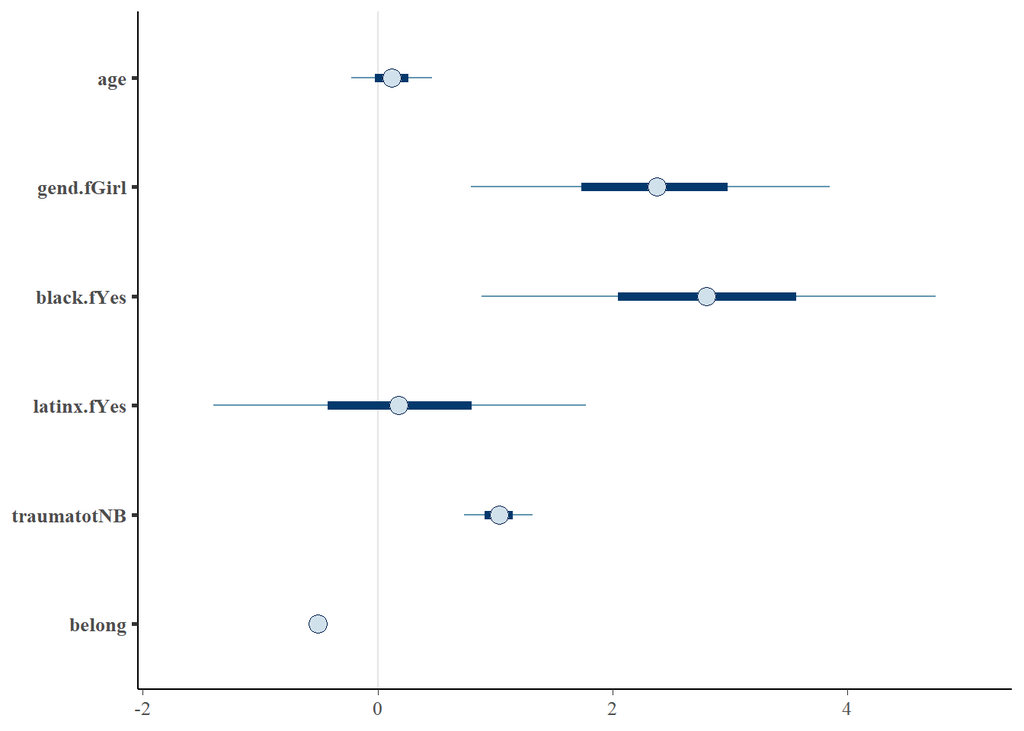

```r
mcmc_intervals(posteriors1,
               pars = c("age","gend.fGirl","black.fYes","latinx.fYes","traumatotNB", "belong"))
```